# Who benefits? Socioeconomic profile of ecosystem-service beneficiary areas

HDI, Gini and GDP disproportionality test on the beneficiary buffer masks — Phase 4 of the 5-variable change hotspot redesign.

24 August 2026

Global NCP Hotspot Analysis — Memo

Prepared by Jerónimo Rodríguez Escobar Global Science, WWF 24 August 2026

## Key findings

**Inequality.** Beneficiary areas skew toward **more unequal (higher-Gini)** regions — and that skew gets **stronger**, not weaker, in the most compound-risk cells (4+ services). *(δ 0.22 at combined-cross/3+, rising to 0.33 at 4+.)*

**Development.** HDI shows **no meaningful relationship** in either direction — beneficiary status isn’t tied to human development level. *(δ 0.04–0.10, negligible–small.)*

## Question

> Apply the union coverage masks to the HDI, Gini, and GDP rasters to test whether beneficiary areas — combined cross-category, or the 3+/4+ hotspot tiers — are disproportionately high or low compared to outside.

## Analysis Performed

[output not shown]

**Beneficiary categories.** 8 possible categories exist.

| Category | What it means | Used here? |
| --- | --- | --- |
| Water-overlap | Cell has a water-pathway hotspot (sediment or nitrogen export) | No |
| Access-overlap | Cell has an access-pathway hotspot (nature access, pollination, or coastal risk) | No |
| **Combined cross-category** | Cell has *both* a water-pathway *and* an access-pathway hotspot at once | **Yes** |
| 1+ services | Cell has at least 1 of the 5 tracked services in extreme change | No |
| 2+ services | Cell has at least 2 of the 5 tracked services in extreme change | No |
| **3+ services** | Cell has at least 3 of the 5 tracked services in extreme change | **Yes** |
| **4+ services** | Cell has at least 4 of the 5 tracked services in extreme change | **Yes** |
| 5 services (all) | Cell has all 5 tracked services in extreme change at once | No — also nearly empty, 364 cells worldwide |

Population figures in this report (4.1B / 2.3B / 872M “people reached”) come from **LandScan Global 2023** — a different population dataset than `GHS_POP_E2020_GLOBE_sum`, the population variable used in the HDI/Gini/GDP statistical test.

**Combined cross-category** — at least 1 of the 2 water services *and* at least 1 of the 3 access services. The underlying extraction function (`derive_cross_combo()`, `R/get_hotspots.R`) can cross *any* named service groups with AND/OR logic, at any threshold.

**How a cell qualifies, step by step.** Two independent stages, each with its own AND/OR — easy to conflate “which services” with “which buffer.” Diagram below shows the **union** version specifically — Stage 2’s final gate is OR. The intersection alternative (see below) swaps that one gate to AND; Stage 1 is identical either way.

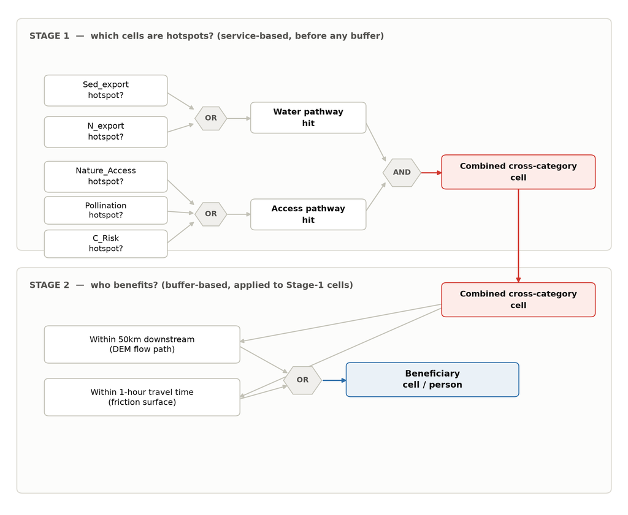

Two-stage AND/OR flowchart for the union definition: Stage 1 defines which cells are hotspots by service. In this case, Stage 2’s final OR operator means “reached by either buffer” — the intersection alternative swaps this gate to AND (intersection of both buffers)

**What “reach” means.** For each category, a person counts as reached if they’re within 50km downstream (river network) *or* within 1 hour’s travel (roads) of any qualifying cell — either buffer counts, not both. 4.1B / 2.3B / 872M are this same “either buffer” reach applied to combined-cross-category / 3+ / 4+ cells respectively.

**Union (“either buffer”) vs. intersection (“both buffers”) — how much smaller is “both”?**

| Category | Union: land % / cells | Intersection: land % / cells | Intersection ÷ union |
| --- | --- | --- | --- |
| Combined cross-cat. | 23.6% / 321K | 10.2% / 139K | 43% |
| 3+ services | 12.8% / 174K | 5.2% / 71K | 41% |
| 4+ services | 4.4% / 60K | 1.6% / 22K | 37% |

Intersection is roughly 40% the size across all three categories — a consistent pattern. Whether the *statistical* results hold up under this stricter definition too is checked in the Effect size section below.

**Extracted masks.** Combined cross-category, all 4 mask types, shown at their **source resolution (~0.93km / 30 arcsec)** Global extent (decimated for display) + zoomed Amazon/Andes inset (native resolution) for each.

Downstream (50km) Travel-time (1hr) Union (either) Intersection (both)

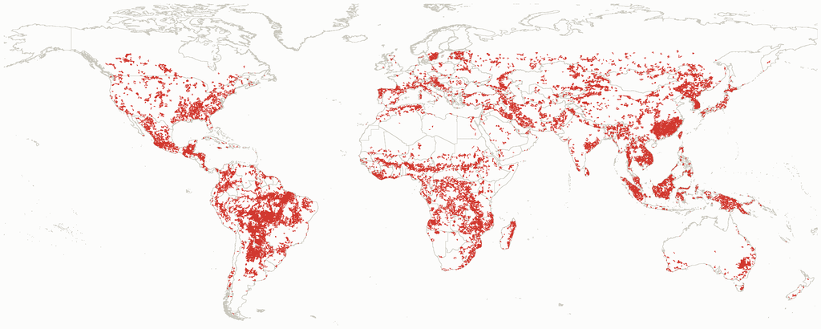

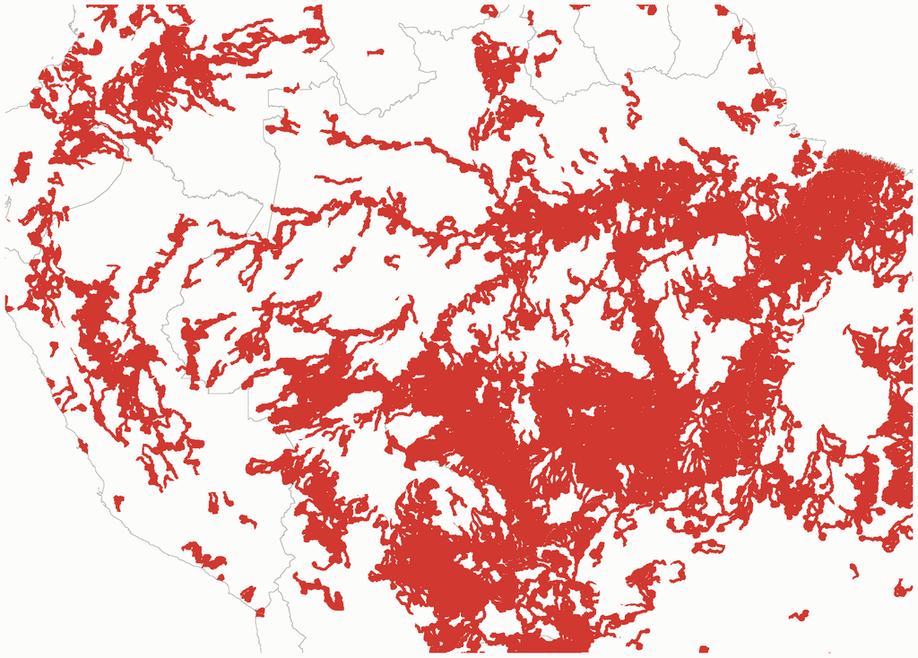

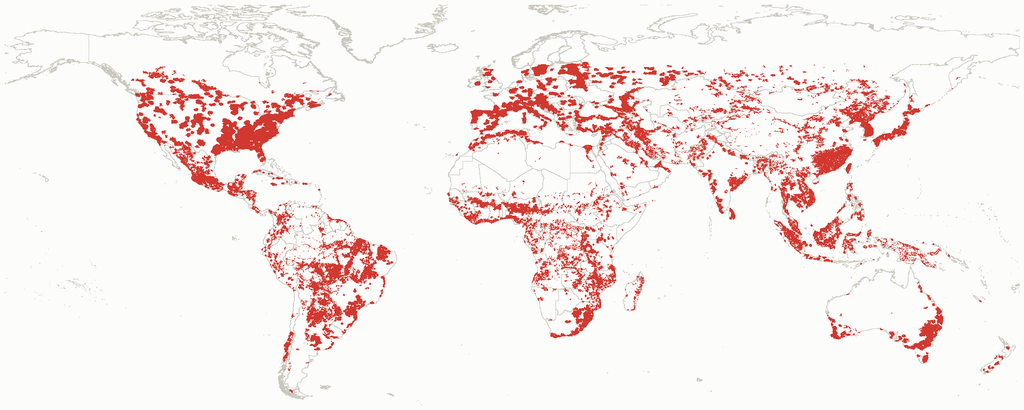

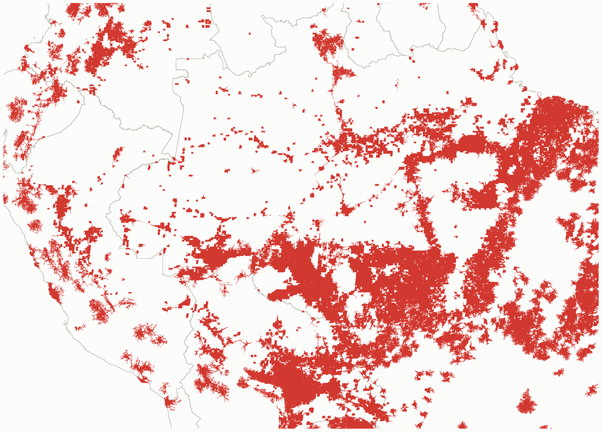

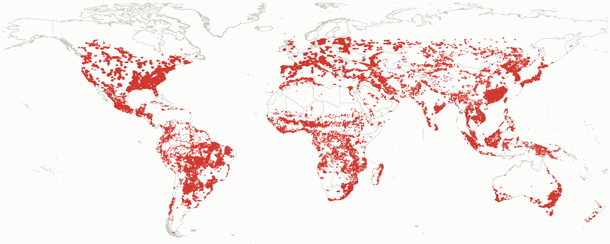

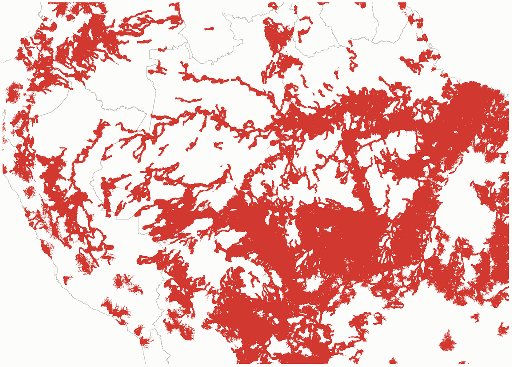

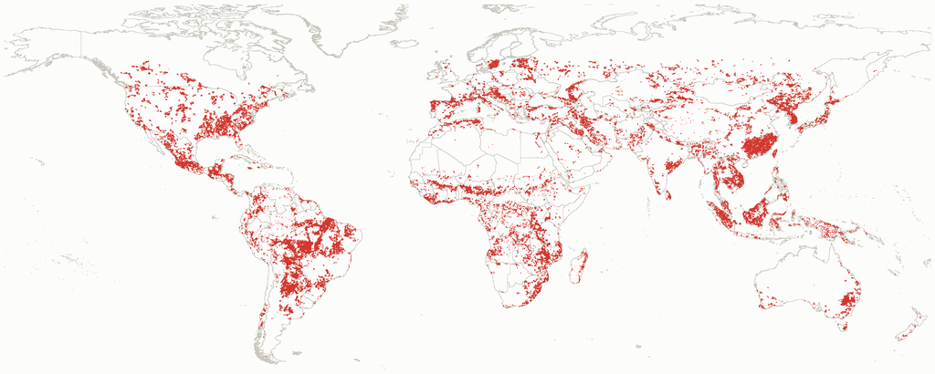

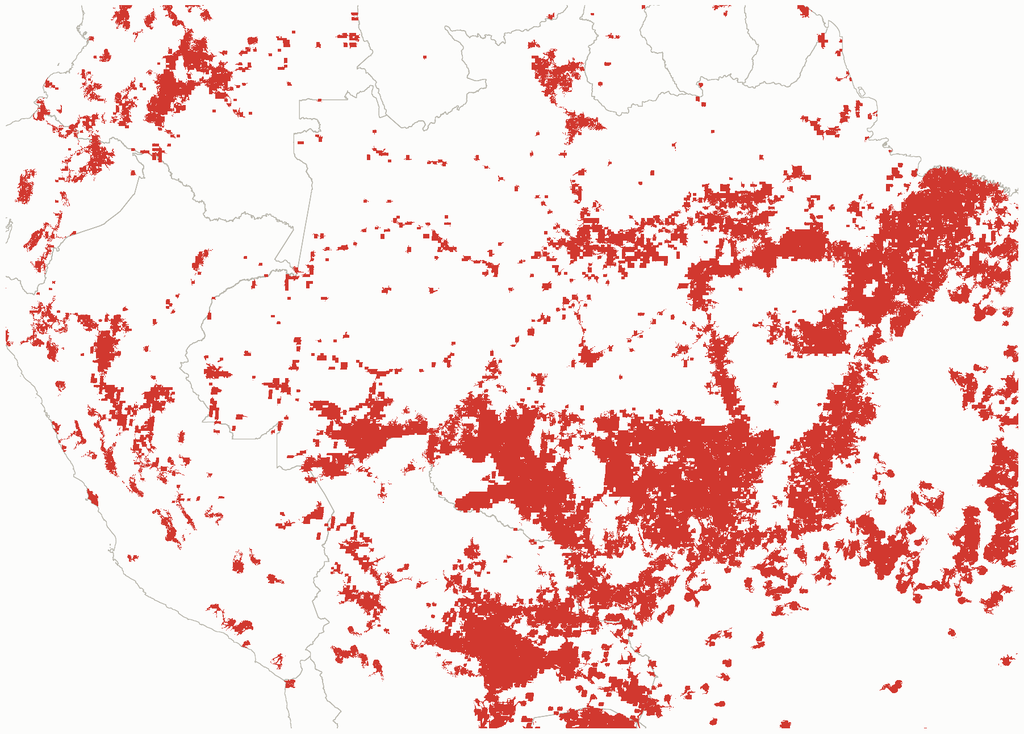

## Effect size by variable

GDP

rast_gdpTot_2020, cell sum

Population

GHS_POP 2020, cell sum

Gini

rast_adm1_gini_disp_2020, cell mean

HDI

hdi_raster_predictions_2020, cell mean

Cliff's delta (beneficiary higher than outside)

Dashed ticks: 0.15 / small · 0.33 / medium · 0.47 / large

| Variable | Union δ | Intersection δ | Robust? |
| --- | --- | --- | --- |
| GDP | 0.49–0.53 | 0.51–0.54 | Yes |
| Population | 0.48–0.52 | 0.50–0.54 | Yes |
| Gini | 0.22–0.33 | 0.22–0.38 | Yes — stronger |
| HDI | 0.04–0.10 | −0.01–0.04 | No — sign flips at 4+ |

Full numbers: `data/processed/tables/union_vs_intersection_comparison.csv`.

## Distribution comparison

GDP

log scale — q10-q90 range, tick = median

Population

log scale — q10-q90 range, tick = median

Gini

linear scale — q10-q90 range, tick = median

HDI

linear scale — q10-q90 range, tick = median

Inside beneficiary mask

Outside beneficiary mask

## Output numbers

Median value per 10km cell, inside the beneficiary mask vs. outside it. GDP and population totals are extensive (summed per cell), so medians read low relative to the totals above — most cells are small, a few are enormous.

| Variable | Category | Median, inside | Median, outside | Cliff’s δ |
| --- | --- | --- | --- | --- |
| GDP | Combined cross-cat. | $7.16M | $3.9K | **0.53** |
|  | 3+ services | $9.83M | $28.5K | **0.53** |
|  | 4+ services | $9.19M | $81.9K | **0.49** |
| Population | Combined cross-cat. | 849 | 0.19 | **0.52** |
|  | 3+ services | 1,116 | 2.2 | **0.52** |
|  | 4+ services | 1,080 | 6.9 | **0.48** |
| Gini | Combined cross-cat. | 0.355 | 0.321 | **0.22** |
|  | 3+ services | 0.359 | 0.322 | **0.22** |
|  | 4+ services | 0.389 | 0.328 | **0.33** |
| HDI | Combined cross-cat. | 0.674 | 0.661 | **0.08** |
|  | 3+ services | 0.677 | 0.663 | **0.10** |
|  | 4+ services | 0.663 | 0.666 | **0.04** |

All 12 differences are statistically significant at p < 0.001 (two-sided KS test, Benjamini–Hochberg corrected) — sample sizes range from ~60K to ~320K beneficiary cells against ~1.0–1.3M non-beneficiary cells, so even the smaller HDI effect is not noise.

## Discussion

**Gini** is the least obvious result but probably the most useful: beneficiary areas skew toward more unequal regions, not less, and — unlike GDP and population — that effect *grows* at the most exclusive tier (δ 0.22 at combined-cross and 3+, rising to 0.33 at 4+). The people gaining the most concentrated ecosystem-service benefit are disproportionately in places with more internal inequality, not fewer.

**Why GDP flattens while Gini keeps climbing, at the same tier.** GDP measures average wealth level; Gini measures how unequally that wealth is distributed within a place — different dimensions. GDP’s gap doesn’t grow at the 4+ tier (δ 0.53 → 0.49) — the wealth relationship is already near its ceiling by “combined cross” / “3+,” and the most severe compound-risk cells aren’t concentrated *even more* in rich places. Gini’s gap does grow (0.22 → 0.33) at that same tier. So the story isn’t “compound risk concentrates in rich places” — GDP alone would show that as a strengthening trend too, and it doesn’t. It’s specifically “compound risk concentrates in unequal places,” a distinct, more distributional signal that GDP by itself would miss entirely.

**HDI** shows essentially no relationship (δ ≈ 0.04–0.10, negligible to small) — human development level doesn’t meaningfully predict beneficiary status either way.

This is a co-occurrence pattern, not a causal claim — the test says where these buffers geographically land relative to wealth, population, inequality, and development, not why. It doesn’t imply the ecosystem service itself is delivered unequally by design; it says the buffers currently fall in places that are already wealthier, denser, and more unequal than the rest of the landscape.

## Scope & caveats

[output not shown]

Full results table: `data/processed/tables/ks_results_beneficiary_masks.csv` · Notebook: `analysis/KS_tests_beneficiary_masks.qmd` · Plots: `outputs/plots/ks_beneficiary_masks/`